# Idiographic Personality Network Analyses

DH

November 2nd, 2023

Open necessary libraries

```r
library(tidyverse)
library(car)
library(data.table)
library(psych)
library(plyr)
library(graphicalVAR)
library(qgraph)
library(ppcor)
library(animation)
library(ggplot2)
library(ggplotify)
library(grid)
library(kcpRS)
library(knitr)
```

# Importing data

Import imputed data (see data preparation file)

```r
setwd("//cnas.ru.nl/wrkgrp/FSW-BSI-DP-PhD_Daan_Hulsmans/Study 1 - Feasibility study/Data")
dataset_imp <- read_csv("df_networks_imputed.csv", col_names=T)
dataset_imp <- dataset_imp[,-1]
```

# Preperatory steps

Creating a dataframe to visually inspect variances per item per participant

```r
v <- data.frame(matrix(ncol = 9, nrow = length(unique(dataset_imp$Participant))))
colnames(v) <- c("Participant","Happy", "Worrying","Scared","Nervous","Act_later_regret","Act_without_thinking","Act_for_kicks","Restless")
v[,c("Participant", "Happy")] <- aggregate(Happy ~ Participant, dataset_imp, var)
v[,c("Participant", "Worrying")] <- aggregate(Worrying ~ Participant, dataset_imp, var)
v[,c("Participant", "Scared")] <- aggregate(Scared ~ Participant, dataset_imp, var)
v[,c("Participant", "Nervous")] <- aggregate(Nervous ~ Participant, dataset_imp, var)
v[,c("Participant", "Act_later_regret")] <- aggregate(Act_later_regret ~ Participant, dataset_imp, var)
v[,c("Participant", "Act_without_thinking")] <- aggregate(Act_without_thinking ~ Participant, dataset_imp, var)
v[,c("Participant", "Act_for_kicks")] <- aggregate(Act_for_kicks ~ Participant, dataset_imp, var)
v[,c("Participant", "Restless")] <- aggregate(Restless ~ Participant, dataset_imp, var)
v <- as.data.frame(v)
v
```

```
##    Participant      Happy   Worrying     Scared    Nervous Act_later_regret
## 1            2 0.70169492 1.06666667 0.85734463 0.55480226       0.78954802
## 2            4 0.72853107 0.72853107 0.62005650 0.62033898       0.49717514
## 3            5 0.24039548 0.01666667 0.42344633 0.23276836       0.00000000
## 4            6 0.19745763 0.12542373 0.01666667 0.03276836       0.06327684
## 5            7 1.11412429 0.25395480 0.00000000 0.00000000       0.00000000
## 6            8 0.58644068 0.25395480 0.20649718 0.24293785       0.03276836
## 7            9 1.10847458 1.12542373 0.56497175 0.80338983       0.99745763
## 8           10 0.77288136 2.23276836 0.91412429 1.71073446       0.81666667
## 9           12 0.23615819 0.25988701 0.09717514 0.31497175       0.03276836
## 10          18 0.82344633 1.05084746 0.95480226 0.86412429       0.24293785
## 11          19 0.31073446 0.09152542 0.00000000 0.26525424       0.17937853
## 12          20 0.27683616 0.14548023 0.01666667 0.14124294       0.08220339
## 13          22 0.62259887 0.76271186 0.86864407 0.74463277       0.26666667
## 14          23 0.22005650 0.28107345 0.00000000 0.10480226       0.06327684
```

[output cut: 47 more lines]

Based on visual inspection of this datatframe, we remove four participants and two variables without variance for the rest of the 26 participants

```r
dataset_imp <- subset(dataset_imp, dataset_imp$Participant != "5" &
                        dataset_imp$Participant != "7" &
                        dataset_imp$Participant != "34" &
                        dataset_imp$Participant != "43")
dataset_imp <- dataset_imp[ , !(names(dataset_imp) %in% c("Scared", "Act_for_kicks"))]
```

Descriptive statistics

```r
psych::describe(dataset_imp[,c("age", "tiq")])
```

```
##     vars    n  mean    sd median trimmed   mad min max range  skew kurtosis
## age    1 1560 22.69  5.53   21.5   22.41  5.93  15  33    18  0.42    -1.09
## tiq    2 1380 72.30 10.37   73.0   73.40 10.38  50  85    35 -0.70    -0.47
##       se
## age 0.14
## tiq 0.28
```

```r
count(dataset_imp$gender)
```

```
##        x freq
## 1 Female  900
## 2   Male  660
```

```r
count(dataset_imp$P_Profile)
```

```
##    x freq
## 1 AS  480
## 2 IM  360
## 3 NT  540
## 4 SS  180
```

All freq’s divided by 60 timepoints gives us number of participants

# Autocorrelation functions

Generate Autocorrelation functions per participant

```r
#critical value ACF with 99% CI
CV <- qnorm((1 + 0.99)/2)/sqrt(60)
CV
```

```
## [1] 0.3325381
```

```r
# create empry matrix
acfmatrix <- data.frame(matrix(ncol = 2, nrow = 60))
colnames(acfmatrix) <- c("count_sig_total", "sig_percentage")
rownames(acfmatrix) <- as.numeric(rownames(acfmatrix)) - 1
acfmatrix[is.na(acfmatrix)] <- 0

# fill empty matrix with the counts significant (p < .01; critical acf-value = 0.3325381 at 99% CI) per lag (rows) and per individual (column)
for (j in unique(dataset_imp$Participant)){
  tempacf <- acf(dataset_imp[dataset_imp$Participant == j , -c(1,8:13)], lag.max = 60, plot = FALSE)
  acfmatrix[,paste0("participant", j)] <- 0
  for(i in as.numeric(rownames(acfmatrix))){
    tempmatrix <- tempacf$acf[i,,]
    tempvector <- tempmatrix[upper.tri(tempmatrix, diag = T)]
    acfmatrix[i,paste0("participant", j)] <- length(which(tempvector > 0.3325381 | tempvector < -0.3325381))
  }
}
```

Add summary statistics of counts and percentages across participants

```r
# add summary statistics of counts and percentages across participants
acfmatrix[1,3:28] <- acfmatrix[1,3:28] - 6 # at lag-0 all autocorrelations with same variable are exactly 1. We therefore subtract 6 (for each of the variables) from the denuminator when calculating the percentage of significant associations relative all possible meaningful associations
acfmatrix$count_sig_total <- rowSums(acfmatrix[3:28])
acfmatrix$sig_percentage <- acfmatrix[,"count_sig_total"] / (21*26) # denuminator is 21 (one diagonal of symmetrical matrix, 15, plus the diagnonal 6), for all lags of 1 and above across 26 participants
acfmatrix[1,2] <- acfmatrix[1,"count_sig_total"] / (15*26) # denuminator is 15 for lag-0 (one diagonal of symmetrical matrix, 15, without the diagnonal 6)
kable(acfmatrix, caption = "Table 1. Autocorrelation Functions per participant.")
```

Table 1. Autocorrelation Functions per participant.

|  | count_sig_total | sig_percentage | participant2 | participant4 | participant6 | participant8 | participant9 | participant10 | participant12 | participant18 | participant19 | participant20 | participant22 | participant23 | participant24 | participant25 | participant26 | participant28 | participant29 | participant30 | participant31 | participant32 | participant35 | participant36 | participant37 | participant38 | participant42 | participant44 |
| --- | --- | --- | --- | --- | --- | --- | --- | --- | --- | --- | --- | --- | --- | --- | --- | --- | --- | --- | --- | --- | --- | --- | --- | --- | --- | --- | --- | --- |
| 0 | 151 | 0.3871795 | 14 | 3 | 5 | 5 | 14 | 8 | 3 | 9 | 3 | 5 | 5 | 0 | 4 | 8 | 5 | 1 | 9 | 12 | 4 | 2 | 11 | 3 | 6 | 1 | 5 | 6 |
| 1 | 65 | 0.1190476 | 0 | 1 | 0 | 1 | 7 | 0 | 2 | 5 | 2 | 0 | 3 | 3 | 1 | 0 | 3 | 8 | 0 | 6 | 2 | 4 | 7 | 3 | 2 | 4 | 1 | 0 |
| 2 | 31 | 0.0567766 | 1 | 1 | 4 | 1 | 1 | 0 | 2 | 1 | 1 | 0 | 0 | 1 | 1 | 0 | 2 | 5 | 0 | 0 | 1 | 4 | 1 | 1 | 0 | 3 | 0 | 0 |
| 3 | 17 | 0.0311355 | 0 | 0 | 3 | 0 | 1 | 0 | 1 | 1 | 1 | 1 | 0 | 1 | 0 | 0 | 1 | 2 | 0 | 0 | 0 | 2 | 0 | 1 | 0 | 2 | 0 | 0 |
| 4 | 14 | 0.0256410 | 0 | 0 | 1 | 1 | 0 | 0 | 2 | 0 | 0 | 0 | 0 | 1 | 0 | 0 | 0 | 0 | 0 | 1 | 0 | 2 | 0 | 3 | 0 | 3 | 0 | 0 |
| 5 | 22 | 0.0402930 | 0 | 1 | 1 | 0 | 0 | 0 | 3 | 0 | 1 | 0 | 0 | 2 | 2 | 0 | 2 | 2 | 0 | 1 | 1 | 4 | 1 | 0 | 0 | 1 | 0 | 0 |
| 6 | 16 | 0.0293040 | 0 | 0 | 0 | 0 | 0 | 1 | 2 | 0 | 1 | 0 | 0 | 1 | 1 | 1 | 3 | 3 | 0 | 0 | 0 | 1 | 1 | 0 | 0 | 0 | 1 | 0 |
| 7 | 19 | 0.0347985 | 0 | 0 | 1 | 1 | 0 | 0 | 2 | 0 | 3 | 0 | 1 | 1 | 0 | 0 | 0 | 2 | 0 | 0 | 0 | 2 | 0 | 3 | 0 | 3 | 0 | 0 |
| 8 | 6 | 0.0109890 | 0 | 0 | 0 | 0 | 0 | 0 | 4 | 0 | 0 | 0 | 0 | 0 | 0 | 0 | 0 | 0 | 0 | 0 | 0 | 0 | 0 | 0 | 0 | 1 | 0 | 1 |
| 9 | 11 | 0.0201465 | 0 | 0 | 1 | 0 | 0 | 0 | 2 | 0 | 0 | 0 | 0 | 1 | 0 | 0 | 1 | 0 | 0 | 0 | 0 | 0 | 1 | 1 | 0 | 1 | 3 | 0 |
| 10 | 7 | 0.0128205 | 0 | 0 | 0 | 0 | 0 | 0 | 0 | 0 | 2 | 2 | 0 | 1 | 0 | 0 | 0 | 0 | 0 | 0 | 0 | 0 | 1 | 0 | 0 | 1 | 0 | 0 |
| 11 | 12 | 0.0219780 | 0 | 0 | 1 | 0 | 0 | 0 | 2 | 0 | 0 | 0 | 2 | 1 | 0 | 0 | 0 | 2 | 0 | 0 | 0 | 0 | 3 | 0 | 0 | 1 | 0 | 0 |
| 12 | 8 | 0.0146520 | 0 | 0 | 1 | 0 | 0 | 1 | 1 | 1 | 1 | 0 | 0 | 1 | 0 | 0 | 0 | 2 | 0 | 0 | 0 | 0 | 0 | 0 | 0 | 0 | 0 | 0 |
| 13 | 6 | 0.0109890 | 0 | 0 | 0 | 1 | 1 | 0 | 1 | 0 | 1 | 0 | 0 | 2 | 0 | 0 | 0 | 0 | 0 | 0 | 0 | 0 | 0 | 0 | 0 | 0 | 0 | 0 |
| 14 | 12 | 0.0219780 | 0 | 0 | 1 | 4 | 1 | 0 | 1 | 0 | 0 | 1 | 0 | 3 | 0 | 0 | 0 | 0 | 0 | 0 | 1 | 0 | 0 | 0 | 0 | 0 | 0 | 0 |
| 15 | 5 | 0.0091575 | 0 | 0 | 0 | 1 | 0 | 0 | 0 | 0 | 0 | 0 | 0 | 2 | 0 | 1 | 1 | 0 | 0 | 0 | 0 | 0 | 0 | 0 | 0 | 0 | 0 | 0 |
| 16 | 3 | 0.0054945 | 0 | 0 | 0 | 0 | 0 | 0 | 0 | 0 | 1 | 0 | 0 | 0 | 0 | 0 | 1 | 1 | 0 | 0 | 0 | 0 | 0 | 0 | 0 | 0 | 0 | 0 |
| 17 | 3 | 0.0054945 | 0 | 0 | 0 | 0 | 1 | 0 | 0 | 0 | 1 | 0 | 0 | 0 | 0 | 0 | 0 | 1 | 0 | 0 | 0 | 0 | 0 | 0 | 0 | 0 | 0 | 0 |
| 18 | 0 | 0.0000000 | 0 | 0 | 0 | 0 | 0 | 0 | 0 | 0 | 0 | 0 | 0 | 0 | 0 | 0 | 0 | 0 | 0 | 0 | 0 | 0 | 0 | 0 | 0 | 0 | 0 | 0 |
| 19 | 0 | 0.0000000 | 0 | 0 | 0 | 0 | 0 | 0 | 0 | 0 | 0 | 0 | 0 | 0 | 0 | 0 | 0 | 0 | 0 | 0 | 0 | 0 | 0 | 0 | 0 | 0 | 0 | 0 |
| 20 | 3 | 0.0054945 | 0 | 0 | 1 | 0 | 0 | 0 | 0 | 0 | 0 | 0 | 0 | 0 | 0 | 1 | 1 | 0 | 0 | 0 | 0 | 0 | 0 | 0 | 0 | 0 | 0 | 0 |
| 21 | 4 | 0.0073260 | 0 | 0 | 0 | 0 | 0 | 0 | 0 | 0 | 0 | 0 | 0 | 0 | 0 | 0 | 1 | 2 | 0 | 0 | 0 | 1 | 0 | 0 | 0 | 0 | 0 | 0 |
| 22 | 3 | 0.0054945 | 0 | 0 | 0 | 0 | 0 | 0 | 0 | 0 | 0 | 0 | 0 | 0 | 0 | 0 | 1 | 2 | 0 | 0 | 0 | 0 | 0 | 0 | 0 | 0 | 0 | 0 |
| 23 | 7 | 0.0128205 | 0 | 0 | 0 | 0 | 2 | 0 | 0 | 1 | 1 | 0 | 0 | 0 | 2 | 0 | 0 | 0 | 0 | 0 | 0 | 1 | 0 | 0 | 0 | 0 | 0 | 0 |
| 24 | 1 | 0.0018315 | 0 | 0 | 0 | 0 | 0 | 0 | 0 | 0 | 0 | 0 | 0 | 0 | 0 | 0 | 0 | 0 | 0 | 0 | 0 | 0 | 0 | 0 | 0 | 1 | 0 | 0 |
| 25 | 4 | 0.0073260 | 0 | 0 | 1 | 0 | 1 | 0 | 0 | 0 | 0 | 2 | 0 | 0 | 0 | 0 | 0 | 0 | 0 | 0 | 0 | 0 | 0 | 0 | 0 | 0 | 0 | 0 |
| 26 | 4 | 0.0073260 | 0 | 0 | 0 | 1 | 1 | 0 | 2 | 0 | 0 | 0 | 0 | 0 | 0 | 0 | 0 | 0 | 0 | 0 | 0 | 0 | 0 | 0 | 0 | 0 | 0 | 0 |
| 27 | 2 | 0.0036630 | 0 | 0 | 0 | 0 | 1 | 0 | 0 | 0 | 0 | 0 | 0 | 0 | 0 | 0 | 0 | 0 | 0 | 0 | 0 | 0 | 0 | 1 | 0 | 0 | 0 | 0 |
| 28 | 1 | 0.0018315 | 0 | 0 | 0 | 0 | 0 | 0 | 0 | 0 | 0 | 0 | 0 | 0 | 1 | 0 | 0 | 0 | 0 | 0 | 0 | 0 | 0 | 0 | 0 | 0 | 0 | 0 |
| 29 | 3 | 0.0054945 | 0 | 0 | 0 | 0 | 0 | 0 | 0 | 0 | 0 | 0 | 0 | 0 | 1 | 0 | 2 | 0 | 0 | 0 | 0 | 0 | 0 | 0 | 0 | 0 | 0 | 0 |
| 30 | 1 | 0.0018315 | 0 | 0 | 0 | 0 | 0 | 0 | 0 | 0 | 0 | 0 | 0 | 0 | 0 | 0 | 0 | 0 | 0 | 0 | 0 | 1 | 0 | 0 | 0 | 0 | 0 | 0 |
| 31 | 0 | 0.0000000 | 0 | 0 | 0 | 0 | 0 | 0 | 0 | 0 | 0 | 0 | 0 | 0 | 0 | 0 | 0 | 0 | 0 | 0 | 0 | 0 | 0 | 0 | 0 | 0 | 0 | 0 |
| 32 | 1 | 0.0018315 | 0 | 0 | 0 | 0 | 0 | 0 | 0 | 0 | 0 | 0 | 0 | 0 | 0 | 0 | 0 | 0 | 0 | 0 | 0 | 0 | 0 | 1 | 0 | 0 | 0 | 0 |
| 33 | 3 | 0.0054945 | 0 | 0 | 0 | 0 | 0 | 0 | 1 | 0 | 0 | 0 | 0 | 0 | 0 | 0 | 0 | 0 | 0 | 0 | 0 | 0 | 0 | 0 | 0 | 0 | 2 | 0 |
| 34 | 1 | 0.0018315 | 0 | 0 | 0 | 0 | 0 | 0 | 0 | 0 | 0 | 0 | 0 | 0 | 0 | 0 | 1 | 0 | 0 | 0 | 0 | 0 | 0 | 0 | 0 | 0 | 0 | 0 |
| 35 | 6 | 0.0109890 | 0 | 0 | 0 | 0 | 0 | 0 | 0 | 0 | 0 | 5 | 0 | 0 | 0 | 0 | 1 | 0 | 0 | 0 | 0 | 0 | 0 | 0 | 0 | 0 | 0 | 0 |
| 36 | 0 | 0.0000000 | 0 | 0 | 0 | 0 | 0 | 0 | 0 | 0 | 0 | 0 | 0 | 0 | 0 | 0 | 0 | 0 | 0 | 0 | 0 | 0 | 0 | 0 | 0 | 0 | 0 | 0 |
| 37 | 1 | 0.0018315 | 0 | 0 | 0 | 0 | 0 | 0 | 0 | 0 | 0 | 0 | 0 | 0 | 1 | 0 | 0 | 0 | 0 | 0 | 0 | 0 | 0 | 0 | 0 | 0 | 0 | 0 |
| 38 | 3 | 0.0054945 | 0 | 0 | 0 | 0 | 0 | 0 | 0 | 0 | 0 | 0 | 0 | 0 | 1 | 0 | 0 | 0 | 0 | 0 | 0 | 0 | 0 | 1 | 1 | 0 | 0 | 0 |
| 39 | 0 | 0.0000000 | 0 | 0 | 0 | 0 | 0 | 0 | 0 | 0 | 0 | 0 | 0 | 0 | 0 | 0 | 0 | 0 | 0 | 0 | 0 | 0 | 0 | 0 | 0 | 0 | 0 | 0 |
| 40 | 0 | 0.0000000 | 0 | 0 | 0 | 0 | 0 | 0 | 0 | 0 | 0 | 0 | 0 | 0 | 0 | 0 | 0 | 0 | 0 | 0 | 0 | 0 | 0 | 0 | 0 | 0 | 0 | 0 |
| 41 | 0 | 0.0000000 | 0 | 0 | 0 | 0 | 0 | 0 | 0 | 0 | 0 | 0 | 0 | 0 | 0 | 0 | 0 | 0 | 0 | 0 | 0 | 0 | 0 | 0 | 0 | 0 | 0 | 0 |
| 42 | 0 | 0.0000000 | 0 | 0 | 0 | 0 | 0 | 0 | 0 | 0 | 0 | 0 | 0 | 0 | 0 | 0 | 0 | 0 | 0 | 0 | 0 | 0 | 0 | 0 | 0 | 0 | 0 | 0 |
| 43 | 0 | 0.0000000 | 0 | 0 | 0 | 0 | 0 | 0 | 0 | 0 | 0 | 0 | 0 | 0 | 0 | 0 | 0 | 0 | 0 | 0 | 0 | 0 | 0 | 0 | 0 | 0 | 0 | 0 |
| 44 | 2 | 0.0036630 | 0 | 0 | 0 | 0 | 0 | 0 | 0 | 0 | 0 | 0 | 0 | 0 | 0 | 0 | 0 | 2 | 0 | 0 | 0 | 0 | 0 | 0 | 0 | 0 | 0 | 0 |
| 45 | 0 | 0.0000000 | 0 | 0 | 0 | 0 | 0 | 0 | 0 | 0 | 0 | 0 | 0 | 0 | 0 | 0 | 0 | 0 | 0 | 0 | 0 | 0 | 0 | 0 | 0 | 0 | 0 | 0 |
| 46 | 0 | 0.0000000 | 0 | 0 | 0 | 0 | 0 | 0 | 0 | 0 | 0 | 0 | 0 | 0 | 0 | 0 | 0 | 0 | 0 | 0 | 0 | 0 | 0 | 0 | 0 | 0 | 0 | 0 |
| 47 | 0 | 0.0000000 | 0 | 0 | 0 | 0 | 0 | 0 | 0 | 0 | 0 | 0 | 0 | 0 | 0 | 0 | 0 | 0 | 0 | 0 | 0 | 0 | 0 | 0 | 0 | 0 | 0 | 0 |
| 48 | 0 | 0.0000000 | 0 | 0 | 0 | 0 | 0 | 0 | 0 | 0 | 0 | 0 | 0 | 0 | 0 | 0 | 0 | 0 | 0 | 0 | 0 | 0 | 0 | 0 | 0 | 0 | 0 | 0 |
| 49 | 2 | 0.0036630 | 0 | 0 | 0 | 0 | 0 | 0 | 0 | 0 | 0 | 0 | 0 | 0 | 0 | 0 | 0 | 0 | 0 | 0 | 0 | 0 | 0 | 0 | 2 | 0 | 0 | 0 |
| 50 | 1 | 0.0018315 | 0 | 0 | 0 | 0 | 0 | 0 | 0 | 0 | 0 | 0 | 0 | 0 | 0 | 0 | 0 | 0 | 0 | 0 | 0 | 0 | 0 | 0 | 0 | 1 | 0 | 0 |
| 51 | 0 | 0.0000000 | 0 | 0 | 0 | 0 | 0 | 0 | 0 | 0 | 0 | 0 | 0 | 0 | 0 | 0 | 0 | 0 | 0 | 0 | 0 | 0 | 0 | 0 | 0 | 0 | 0 | 0 |
| 52 | 0 | 0.0000000 | 0 | 0 | 0 | 0 | 0 | 0 | 0 | 0 | 0 | 0 | 0 | 0 | 0 | 0 | 0 | 0 | 0 | 0 | 0 | 0 | 0 | 0 | 0 | 0 | 0 | 0 |
| 53 | 1 | 0.0018315 | 0 | 0 | 0 | 0 | 0 | 0 | 0 | 0 | 0 | 0 | 0 | 0 | 1 | 0 | 0 | 0 | 0 | 0 | 0 | 0 | 0 | 0 | 0 | 0 | 0 | 0 |
| 54 | 0 | 0.0000000 | 0 | 0 | 0 | 0 | 0 | 0 | 0 | 0 | 0 | 0 | 0 | 0 | 0 | 0 | 0 | 0 | 0 | 0 | 0 | 0 | 0 | 0 | 0 | 0 | 0 | 0 |
| 55 | 0 | 0.0000000 | 0 | 0 | 0 | 0 | 0 | 0 | 0 | 0 | 0 | 0 | 0 | 0 | 0 | 0 | 0 | 0 | 0 | 0 | 0 | 0 | 0 | 0 | 0 | 0 | 0 | 0 |
| 56 | 0 | 0.0000000 | 0 | 0 | 0 | 0 | 0 | 0 | 0 | 0 | 0 | 0 | 0 | 0 | 0 | 0 | 0 | 0 | 0 | 0 | 0 | 0 | 0 | 0 | 0 | 0 | 0 | 0 |
| 57 | 0 | 0.0000000 | 0 | 0 | 0 | 0 | 0 | 0 | 0 | 0 | 0 | 0 | 0 | 0 | 0 | 0 | 0 | 0 | 0 | 0 | 0 | 0 | 0 | 0 | 0 | 0 | 0 | 0 |
| 58 | 0 | 0.0000000 | 0 | 0 | 0 | 0 | 0 | 0 | 0 | 0 | 0 | 0 | 0 | 0 | 0 | 0 | 0 | 0 | 0 | 0 | 0 | 0 | 0 | 0 | 0 | 0 | 0 | 0 |
| 59 | 0 | 0.0000000 | 0 | 0 | 0 | 0 | 0 | 0 | 0 | 0 | 0 | 0 | 0 | 0 | 0 | 0 | 0 | 0 | 0 | 0 | 0 | 0 | 0 | 0 | 0 | 0 | 0 | 0 |

# Idiographic Network analyses

## Two examples participants

Networks for two example participants in manuscript

```r
df.1 <- dataset_imp[dataset_imp$Participant == 2,-c(1,8:13)]
outcome.1 <- graphicalVAR(df.1, lags = 1)
```

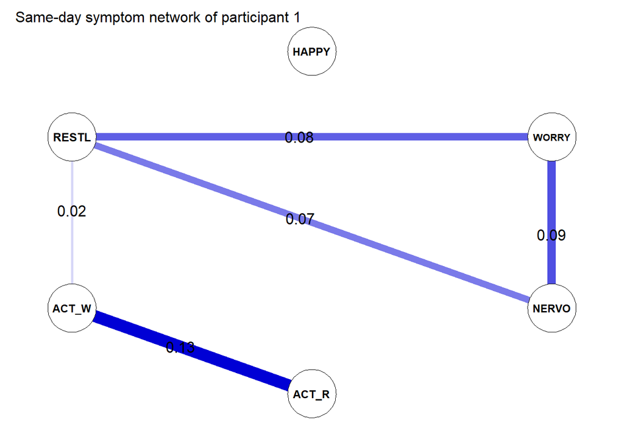

```r
qgraph(outcome.1$PCC, # PCC = partical contemporaneous correlations
       layout = "circle",
       title = paste("Same-day symptom network of participant 1"),
       edge.labels = T,
       edge.label.color = "black",
       edge.label.bg = F,
       edge.label.cex = 1.2,
       label.font = 2,
       theme = "colorblind",
       labels = c("HAPPY","WORRY","NERVO","ACT_R","ACT_W","RESTL"))
```

```r
df.2 <- dataset_imp[dataset_imp$Participant == 4,-c(1,8:13)]
outcome.2 <- graphicalVAR(df.2, gamma = 0.5, lags = 1)
```

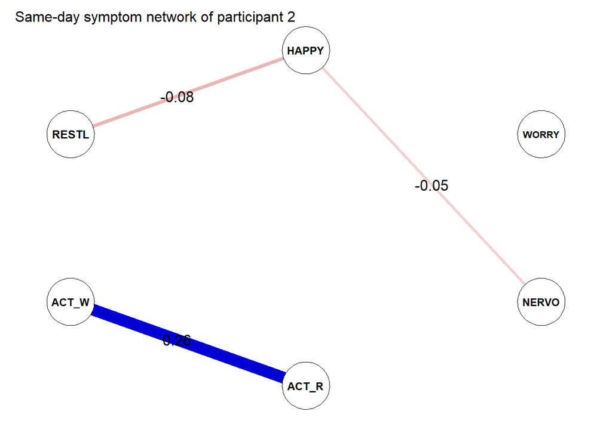

```r
qgraph(outcome.2$PCC,
       layout = "circle",
       title = paste("Same-day symptom network of participant 2"),
       edge.labels = T,
       edge.label.color = "black",
       edge.label.bg = F,
       edge.label.cex = 1.2,
       label.font = 2,
       theme = "colorblind",
       labels = c("HAPPY","WORRY","NERVO","ACT_R","ACT_W","RESTL"))
```

# Between-person network homogeneity

Loop creating networks per participant plus data frame with counts for whole sample and per subgroup that consists of personality profile. Each idiographic network is saved as a .jpeg. First we estimate the matrices within (sub)groups

```r
for(i in unique(dataset_imp$Participant)){
  df.t <- dataset_imp[dataset_imp$Participant == i,-1]
  subgr_p <- as.character(df.t[1,"P_Profile"])
  df.t <- df.t[,-c(7:12)]
  outcome <- graphicalVAR(df.t, gamma = 0.5, lags = 1)
  jpeg(paste("Network ", i, ".jpeg", sep = ""), units = 'in', width = 15, height = 15, res = 600)
  qgraph(outcome$PCC, layout = "circle", title = paste("Same-day symptom network of participant ", i, sep = ""), label.font = 2, theme = "colorblind", labels = c("HAPPY","WORRY","NERV.","ACT_R","ACT_W","RESTL"))
  dev.off()
  temp.group.pos <- as.data.frame(ifelse(outcome$PCC > 0, 1, 0))
  df_pos <- temp.group.pos + df_pos
  temp.group.neg <- as.data.frame(ifelse(outcome$PCC < 0, 1, 0))
  df_neg <- temp.group.neg + df_neg
  if(subgr_p == "AS"){
    temp.subgroup.pos <- as.data.frame(ifelse(outcome$PCC > 0, 1, 0))
    AS_df_pos <- temp.subgroup.pos + AS_df_pos
    temp.subgroup.neg <- as.data.frame(ifelse(outcome$PCC < 0, 1, 0))
    AS_df_neg <- temp.subgroup.neg + AS_df_neg
  }
  if(subgr_p == "NT"){
    temp.subgroup.pos <- as.data.frame(ifelse(outcome$PCC > 0, 1, 0))
    NT_df_pos <- temp.subgroup.pos + NT_df_pos
    temp.subgroup.neg <- as.data.frame(ifelse(outcome$PCC < 0, 1, 0))
    NT_df_neg <- temp.subgroup.neg + NT_df_neg
  }
  if(subgr_p == "SS"){
    temp.subgroup.pos <- as.data.frame(ifelse(outcome$PCC > 0, 1, 0))
    SS_df_pos <- temp.subgroup.pos + SS_df_pos
    temp.subgroup.neg <- as.data.frame(ifelse(outcome$PCC < 0, 1, 0))
    SS_df_neg <- temp.subgroup.neg + SS_df_neg
  }
  if(subgr_p == "IM"){
    temp.subgroup.pos <- as.data.frame(ifelse(outcome$PCC > 0, 1, 0))
    IM_df_pos <- temp.subgroup.pos + IM_df_pos
    temp.subgroup.neg <- as.data.frame(ifelse(outcome$PCC < 0, 1, 0))
    IM_df_neg <- temp.subgroup.neg + IM_df_neg
  }
}
```

After this we can visualize them as networks. Below we visualize all group- and sub-grouplevel networks from counts matrices using the color matrix and save a .jpeg to directory

```r
## Create color matrix for group-level networks
colmat <- data.frame(matrix(ncol = 6, nrow = 6))
x <- c("Happy", "Worrying", "Nervous", "Act_later_regret", "Act_without_thinking", "Restless")
colnames(colmat) <- x
rownames(colmat) <- x
colmat[is.na(colmat)] <- 0
colmat[upper.tri(colmat)] <- "red"
colmat[lower.tri(colmat, diag = T)] <- "blue"
```

```r
## Visualize all group- and sub-grouplevel networks from counts matrices using the color matrix and save a .jpeg to directory
countsmatrix <- as.matrix(df_pos)
countsmatrix[upper.tri(countsmatrix)] <- df_neg[upper.tri(df_neg)]
jpeg("Summary_plot_labels.jpeg", units = 'in', width = 5, height = 5, res = 600)
summaryplot <- qgraph(countsmatrix,
                      layout = "circle",
                      esize = 12,
                      arrows = F,
                      edge.labels = T,
                      edge.label.color = "black",
                      edge.label.bg = F,
                      edge.label.position = 0.6,
                      edge.label.cex = 1.2,
                      curveAll = F,
                      parallelEdge =T,
                      edge.color = as.matrix(colmat),
                      title = "Summary Network total sample (n = 26)",
                      labels = c("HAPPY","WORRY","NERVO","ACT_R","ACT_W","RESTL"))
summaryplot
dev.off()

AS_countsmatrix <- AS_df_pos
AS_countsmatrix[upper.tri(AS_countsmatrix)] <- AS_df_neg[upper.tri(AS_df_neg)]
jpeg("Network Profile AS.jpeg", units = 'in', width = 5, height = 5, res = 600)
AS_summaryplot <- qgraph(AS_countsmatrix,
                         layout = "circle",
                         arrows = F,
                         edge.labels = T,
                         edge.label.color = "black",
                         edge.label.bg = F,
                         edge.label.position = 0.6,
                         edge.label.cex = 1.2,
                         curveAll = F,
                         parallelEdge =T,
                         edge.color = as.matrix(colmat),
                         title = "Summary Network Anxiety Sensitivity (n = 8)",
                         labels = c("HAPPY","WORRY","NERVO","ACT_R","ACT_W","RESTL"))
AS_summaryplot
dev.off()
SS_countsmatrix <- SS_df_pos
SS_countsmatrix[upper.tri(SS_countsmatrix)] <- SS_df_neg[upper.tri(SS_df_neg)]
jpeg("Network Profile SS.jpeg", units = 'in', width = 5, height = 5, res = 600)
SS_summaryplot <- qgraph(SS_countsmatrix,
                         layout = "circle",
                         arrows = F,
                         edge.labels = T,
                         edge.label.color = "black",
                         edge.label.bg = F,
                         edge.label.position = 0.6,
                         edge.label.cex = 1.2,
                         curveAll = F,
                         parallelEdge =T,
                         edge.color = as.matrix(colmat),
                         title = "Summary Network Sensation Seeking (n = 3)",
                         labels = c("HAPPY","WORRY","NERVO","ACT_R","ACT_W","RESTL"))
SS_summaryplot
dev.off()
NT_countsmatrix <- NT_df_pos
NT_countsmatrix[upper.tri(NT_countsmatrix)] <- NT_df_neg[upper.tri(NT_df_neg)]
jpeg("Network Profile NT.jpeg", units = 'in', width = 5, height = 5, res = 600)
NT_summaryplot <- qgraph(NT_countsmatrix,
                         layout = "circle",
                         arrows = F,
                         edge.labels = T,
                         edge.label.color = "black",
                         edge.label.bg = F,
                         edge.label.position = 0.6,
                         edge.label.cex = 1.2,
                         curveAll = F,
                         parallelEdge =T,
                         edge.color = as.matrix(colmat),
                         title = "Summary Network Negative Thinking (n = 9)",
                         labels = c("HAPPY","WORRY","NERVO","ACT_R","ACT_W","RESTL"))
NT_summaryplot
dev.off()
IM_countsmatrix <- IM_df_pos
IM_countsmatrix[upper.tri(IM_countsmatrix)] <- IM_df_neg[upper.tri(IM_df_neg)]
jpeg("Network Profile IM.jpeg", units = 'in', width = 5, height = 5, res = 600)
IM_summaryplot <- qgraph(IM_countsmatrix,
                         layout = "circle",
                         arrows = F,
                         edge.labels = T,
                         edge.label.color = "black",
                         edge.label.bg = F,
                         edge.label.position = 0.6,
                         edge.label.cex = 1.2,
                         curveAll = F,
                         parallelEdge =T,
                         edge.color = as.matrix(colmat),
                         title = "Summary Network Impulsivity (n = 6)",
                         labels = c("HAPPY","WORRY","NERVO","ACT_R","ACT_W","RESTL"))
IM_summaryplot
dev.off()
```

# Idiographic network variability

## Node Strengths

```r
#Create dataframe for table of variability in node strenghts per item, per indidivual
pp_id <- unique(dataset_imp$Participant)
df_strenght <- data.frame(pp_id)
df_strenght$sdwor <- NA
df_strenght$sdner <- NA
df_strenght$sdres <- NA
df_strenght$sdhap <- NA
df_strenght$sdacw <- NA
df_strenght$sdacr <- NA
```

```r
#for loop calculating node strenghts per individual within each 30-day window
for(i in unique(dataset_imp$Participant)){
  temp_data <- dataset_imp[dataset_imp$Participant == i,-c(1,9:13)]

  strengthdf <- data.frame(matrix(nrow=0,ncol=length(6)))

  pcorlist <- list()
  for (d in seq_len(30))
  {
    pcorlist <-  pcor(temp_data[temp_data$Time %in% d:(d+30),c("Happy", "Worrying","Nervous","Act_later_regret","Act_without_thinking","Restless")])$estimate
    vec <- centralityPlot(qgraph(pcorlist, print = FALSE), scale = "raw")$data$value
    strengthdf <- rbind(strengthdf, vec)

    colnames(strengthdf) <- c("worrying","restless","nervous","happy","act_w","act_r")

  }
  # caculating the SD of each node strenghts per item per individual and adding these to a dataframe
  colnames(strengthdf) <- c("worrying","restless","nervous","happy","act_w","act_r")
  df_strenght[df_strenght$pp_id == i,c("sdwor")] <- sd(strengthdf$worrying) # worrying sd
  df_strenght[df_strenght$pp_id == i,c("sdres")] <- sd(strengthdf$restless) # restless sd
  df_strenght[df_strenght$pp_id == i,c("sdner")] <- sd(strengthdf$nervous) # nervous sd
  df_strenght[df_strenght$pp_id == i,c("sdhap")] <- sd(strengthdf$happy) # happy sd
  df_strenght[df_strenght$pp_id == i,c("sdacw")] <- sd(strengthdf$act_w) # act w/o thinking sd
  df_strenght[df_strenght$pp_id == i,c("sdacr")] <- sd(strengthdf$act_r) # act regret sd
}
```

```r
df_strenght$meansdstrength <- rowMeans(df_strenght[,(c("sdwor","sdner", "sdres", "sdhap", "sdacw","sdacr"))], na.rm = TRUE)
```

```r
kable(df_strenght, caption = "Table 1. Results change-points analyses")
```

| pp_id | sdwor | sdner | sdres | sdhap | sdacw | sdacr | meansdstrength |
| --- | --- | --- | --- | --- | --- | --- | --- |
| 2 | 0.2962245 | 0.1846729 | 0.1976040 | 0.1903779 | 0.1592014 | 0.3084042 | 0.2227475 |
| 4 | 0.6955343 | 0.4574654 | 0.2633199 | 0.4355583 | 0.7384747 | 0.5946082 | 0.5308268 |
| 6 | 0.5302595 | 0.3872561 | 0.4334587 | 1.0369530 | 0.9600513 | 0.2213354 | 0.5948857 |
| 8 | 0.3398165 | 0.1522764 | 0.1972123 | 0.4656710 | 0.2346182 | 0.2643429 | 0.2756562 |
| 9 | 0.2431123 | 0.2278838 | 0.2799431 | 0.2229566 | 0.3355960 | 0.2276716 | 0.2561939 |
| 10 | 0.2720693 | 0.0860390 | 0.3389177 | 0.3812549 | 0.3668426 | 0.2220415 | 0.2778608 |
| 12 | 0.1172905 | 0.2307147 | 0.1468253 | 0.2894618 | 0.2429659 | 0.2378712 | 0.2108549 |
| 18 | 0.2721361 | 0.2699758 | 0.1538289 | 0.6104112 | 0.6035374 | 0.2194348 | 0.3548874 |
| 19 | 0.2972487 | 0.2081526 | 0.5180678 | 1.5460752 | 0.3227546 | 0.1431589 | 0.5059096 |
| 20 | 0.4446525 | 0.2334636 | 0.4500563 | 0.5279429 | 0.4495834 | 0.2138784 | 0.3865962 |
| 22 | 0.1204348 | 0.1881388 | 0.2550490 | 0.1617249 | 0.2183251 | 0.1970223 | 0.1901158 |
| 23 | 0.4767825 | 12.7856136 | 1.6952076 | 2.3189639 | 1.1716407 | 5.0623322 | 3.9184234 |
| 24 | 0.1367616 | 0.1183739 | 0.1891255 | 0.2121036 | 0.2805970 | 0.0966474 | 0.1722682 |
| 25 | 0.2548607 | 0.1562217 | 0.2602024 | 0.2046684 | 0.1113403 | 0.2245961 | 0.2019816 |
| 26 | 0.2045497 | 0.4290173 | 0.2271643 | 0.2444724 | 0.1693635 | 0.1642426 | 0.2398016 |
| 28 | 0.4361266 | 0.1923862 | 0.3489449 | 0.1873610 | 0.3990761 | 0.3269142 | 0.3151348 |
| 29 | 0.1807358 | 0.1705390 | 0.2204105 | 0.2467892 | 0.1388336 | 0.1344047 | 0.1819521 |
| 30 | 0.2644471 | 0.2960008 | 0.2035810 | 0.2473619 | 0.3238057 | 0.1516824 | 0.2478132 |
| 31 | 0.2178746 | 0.2300907 | 0.3116367 | 0.2035228 | 0.1958787 | 0.2260932 | 0.2308495 |
| 32 | 0.4092723 | 0.2737020 | 0.2615533 | 4.3563125 | 3.7378940 | 0.2884146 | 1.5545248 |
| 35 | 0.2757131 | 0.2206940 | 0.3044960 | 0.5421542 | 0.1931007 | 0.2694607 | 0.3009365 |
| 36 | 0.5868048 | 0.3773412 | 0.2922724 | 0.4889165 | 0.5130004 | 0.4216575 | 0.4466655 |
| 37 | 0.2318565 | 0.1128533 | 0.2616828 | 0.6412077 | 0.6435864 | 0.1386978 | 0.3383141 |
| 38 | 1.0004539 | 0.7825762 | 0.5328815 | 6.1919976 | 1.5263878 | 0.3180198 | 1.7253862 |
| 42 | 0.1953043 | 0.4840252 | 0.2319392 | 0.1639389 | 0.4837541 | 0.2687608 | 0.3046204 |
| 44 | 0.3631067 | 0.2179197 | 0.4016173 | 0.1459899 | 0.2171223 | 0.2344264 | 0.2633637 |